# RBIF-108: Week 4 Homework

Jonathan Hummel

29 April, 2025

# **Running the analysis**

The code in this section is very similar to that of the Week 4 Script and Week 4 Topic Notes, but was run using the data in the file “s_obj_TA_M.rds” as input instead of “s_obj_AA_M.rds”. As in the lecture notes, the first step was to inspect the cells in a lower-dimensional expression space (i.e. using UMAP) and make sure the clusters/labels made sense:

```r
##########################################
#### Load single cell sequencing data ####
##########################################
# BiocManager::install("Seurat")
library(Seurat); library(ggplot2)
scData <- readRDS("./s_obj_TA_M.rds")
# Proper cell identities were already included in this object upon import,
# as indicated by checking via "levels(scData)" or "Idents(scData)"
levels(scData)
```

```
## [1] "SMC"        "Macrophage" "EC"
```

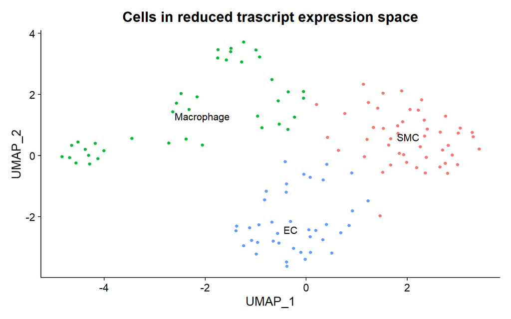

```r
DimPlot(scData, reduction = "umap", label = TRUE, pt.size = 1.2) + NoLegend() + ggtitle("Cells in reduced trascript expression space") + theme(plot.title = element_text(hjust = 0.5))
```

Unlike the example in this week’s lecture notes, this `.rds` file encoded an object that already had labels for the clusters/cell types, which can be seen above. While these are not the tightest clusters, the coloring/clustering seems compelling enough (i.e. not highly noisy/overlapping). It looks like there *might* be some subtypes or sub-populations of certain cells (e.g. macrophages), but it is hard to say without further information.

Below, the data set is further prepared and then used to make a CellChat object. Finally, an analysis is conducted using CellChat to determine which ligand-receptor pairs (and pathways) are likely to be involved in cell-cell communication (CCC) between the different cell types. The plot of the number of significant ligand-receptor pairs identified between all pairs of cell types is plotted at the end to guide further investigation/visualization.

**NOTE:** One modification I had to make to the lecture notes code was to call `CellChat::smoothData()` instead of `CellChat::projectData()` as seen below. Apparently, the developers of `CellChat` changed the name of that function, but the documentation is not yet up-to-date, which I found out about [here](https://github.com/jinworks/CellChat/issues/185) [1].

```r
########################################################## # https://www.nature.com/articles/s41576-020-00292-x
#### Obtain CellChat input files from a Seurat object #### # https://github.com/jinworks/CellChat/tree/main
##########################################################
# install.packages("patchwork")
# devtools::install_github("immunogenomics/presto")
# BiocManager::install("BiocNeighbors")
# devtools::install_github("jinworks/CellChat")
library(CellChat); library(patchwork); options(stringsAsFactors = FALSE)
data.input <- GetAssayData(scData, assay = "RNA", layer = "data") # normalized data matrix
labels <- Idents(scData)
meta <- data.frame(group = labels, row.names = names(labels)) # create a data frame of the cell labels
cellchat <- createCellChat(object = data.input, meta = meta, group.by = "group")
```

```
## [1] "Create a CellChat object from a data matrix"
```

```
## Set cell identities for the new CellChat object
## The cell groups used for CellChat analysis are  SMC, Macrophage, EC
```

```r
## Load data base of ligand-receptor pairs
CellChatDB <- CellChatDB.mouse
# showDatabaseCategory(CellChatDB)
# dplyr::glimpse(CellChatDB$interaction)


## Subset the expression data used to only include the transcripts for ligand-receptors
## we are interested in, i.e. secreted proteins and their protein receptors
CellChatDB.use <- CellChatDB
cellchat@DB <- CellChatDB.use
cellchat <- subsetData(cellchat) # subset the expression data of signaling genes for saving computation cost


## Conduct the actual inference of communications between cell types using CellChat
cellchat <- identifyOverExpressedGenes(cellchat)
cellchat <- identifyOverExpressedInteractions(cellchat)
```

```
## The number of highly variable ligand-receptor pairs used for signaling inference is 201
```

```r
# projectData() is now called smoothData(), but documentation was not updated
# This issue was reported here: https://github.com/jinworks/CellChat/issues/185
cellchat <- smoothData(cellchat, adj = PPI.human)
cellchat <- computeCommunProb(cellchat, raw.use = TRUE)
```

```
## triMean is used for calculating the average gene expression per cell group.
## [1] ">>> Run CellChat on sc/snRNA-seq data <<< [2025-04-29 13:11:58.06993]"
## [1] ">>> CellChat inference is done. Parameter values are stored in `object@options$parameter` <<< [2025-04-29 13:12:20.155517]"
```

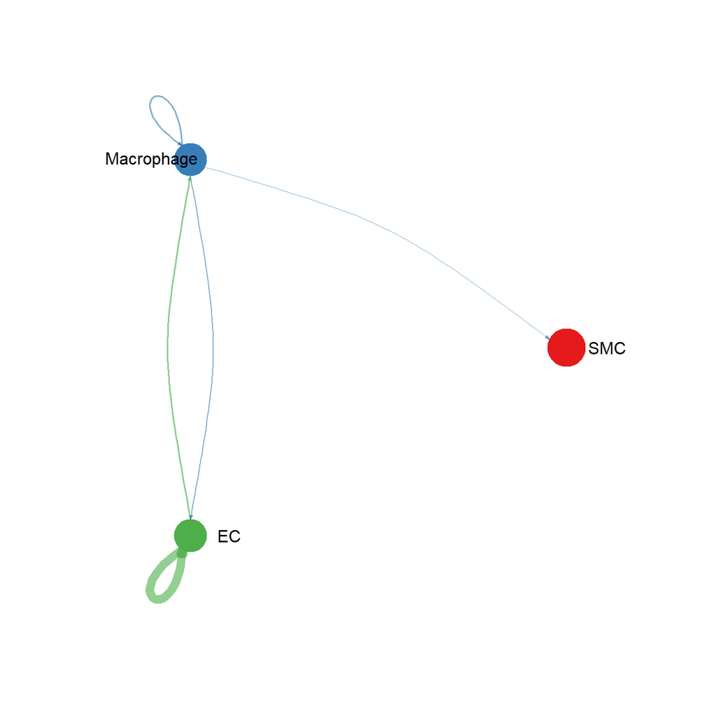

```r
## Filter out the cell-cell communication if there are only few number of cells in certain cell groups
cellchat <- filterCommunication(cellchat, min.cells = 10)
cellchat <- computeCommunProbPathway(cellchat)
cellchat <- aggregateNet(cellchat)
saveRDS(cellchat, file="./cellchat.rds")
# cellchat <- readRDS(file="./cellchat.rds")
groupSize <- as.numeric(table(cellchat@idents))
netVisual_circle(cellchat@net$count, vertex.weight = groupSize, weight.scale = T, label.edge= F, title.name = "Edge width scaled by number of interactions")
```

As seen above, there are not nearly as many interactions identified for this data set as there were for the data set used in the Week 4 Lecture Notes. The most activity by far appears to be autocrine signaling between the endothelial cells (ECs). After that is autocrine signaling between macrophages, followed by a small amount of sending and receiving going on between the ECs and macrophages, with the EC sending accounting for slightly more interactions. Finally there is a very small number of signals being sent from macrophages to smooth muscle cells (SMCs). Due to the high-level picture painted by the plot above, in the next two sections I inspect the pathways driving these connections with more granularity, with a focus on either endothelial cells or macrophages as the senders.

# **ECs as senders**

The easiest way for me to identify the receptor-ligand pairs driving the EC-sending interactions to the other cell types shown above was via the bubble plot and chord diagrams:

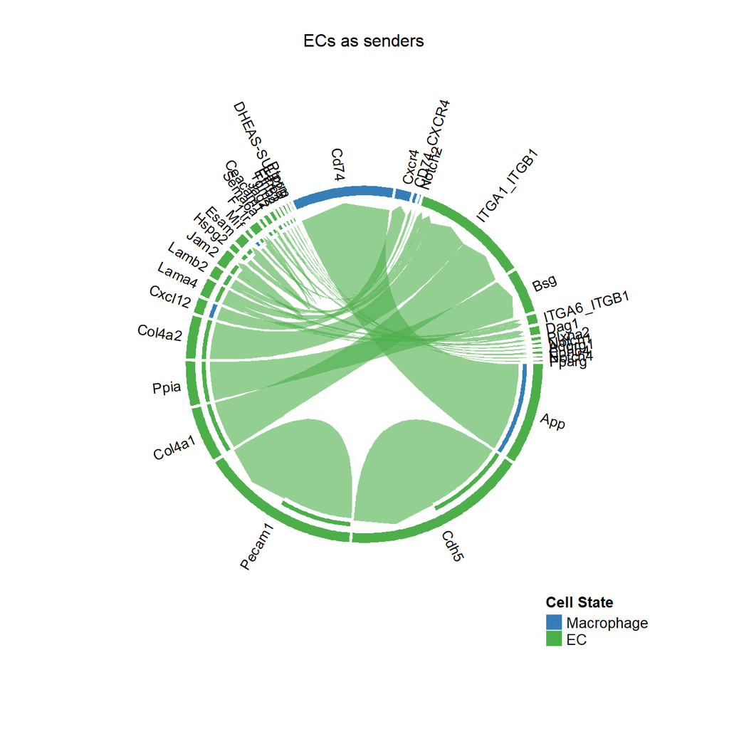

```r
idx <- 1:3
names(idx) <- levels(scData)
sender <- idx["EC"]
receiver <- idx[c("Macrophage","EC")]

## Chord diagram
netVisual_chord_gene(cellchat, sources.use = sender, targets.use = receiver, title.name = "ECs as senders")
```

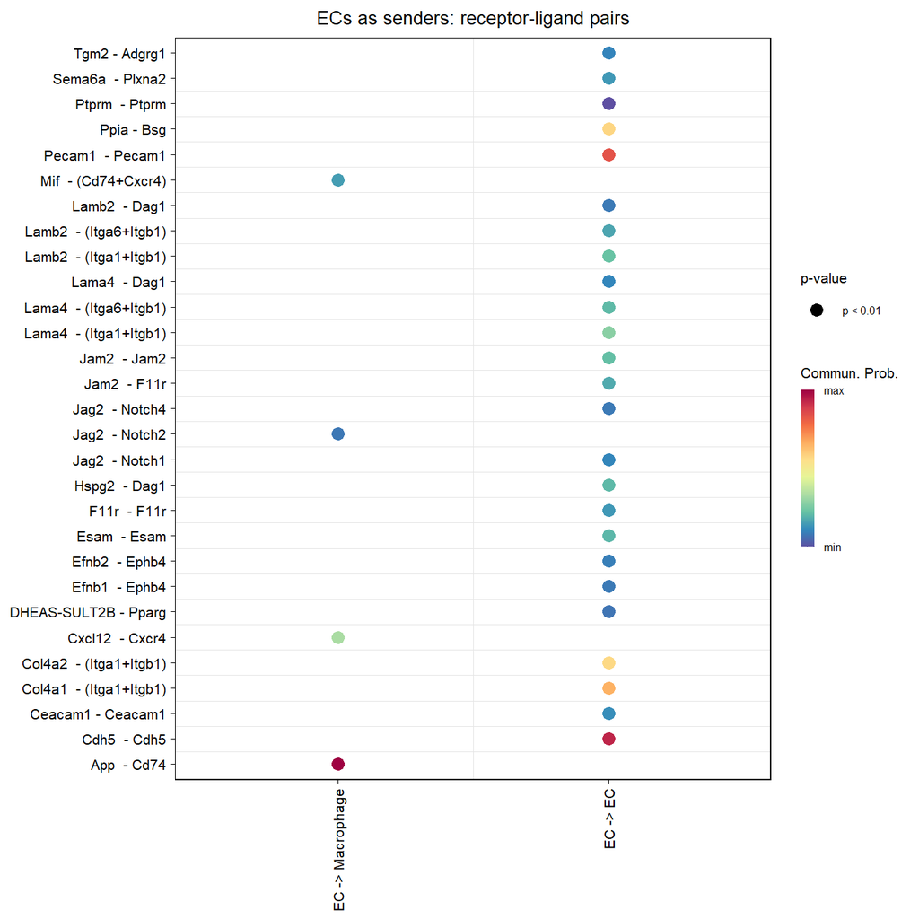

```r
## Bubble plot
netVisual_bubble(cellchat, sources.use = sender, targets.use = receiver, remove.isolate = FALSE, title.name = "ECs as senders: receptor-ligand pairs")
```

The two plots above are different ways of representing essentially the same information. That said, I find the bubble plot a bit more concrete. As seen above, *App-Cd74* is the significant pair with the highest probability of activity for signals sent from endothelial cells to macrophages. As such, I will investigate this pair and its associated pathways further in the next section. As for EC autocrine signaling, there are a number of pairs with moderate to high probabilities of activity. While not super rigorous, because as all relevant pairs shown above are significant, I will use yellow/“moderate” probability in the bubble plot as the cutoff for investigating EC autocrine signaling. This includes the *Cdh5-Cdh5* and *Pecam1-Pecam1* pairs with near-maximum probabilities, and the *Col4a1-(Itga1+Itgb1)*, *Col4a2-(Itga1+Itgb1)*, and *Ppia-Bsg* pairs with more moderate probabilities.

## EC to Macrophage

As discussed above, the *App-Cd74* pair was identified as the strongest/most compelling connection among the significant ones identified between endothelial cells and macrophages. The name of the pathway this pair belongs to can be easily identified, and it can then be investigated a bit further via the visualizations below:

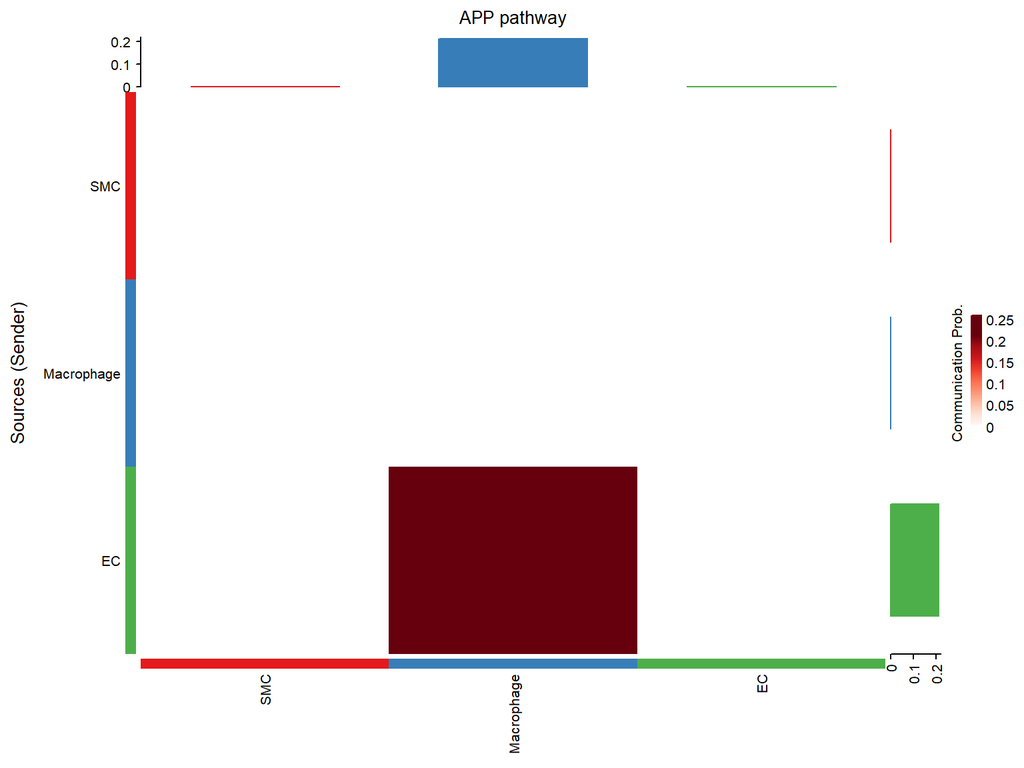

```r
## What is the pathway name for App-Cd74?
pathways.show <- cellchat@LR$LRsig$pathway_name[grepl("App_Cd74", cellchat@LR$LRsig$interaction_name, ignore.case = TRUE)]
## Heatmap
netVisual_heatmap(cellchat, signaling = pathways.show, color.heatmap = "Reds", title.name = paste(pathways.show, " pathway", sep=""))
```

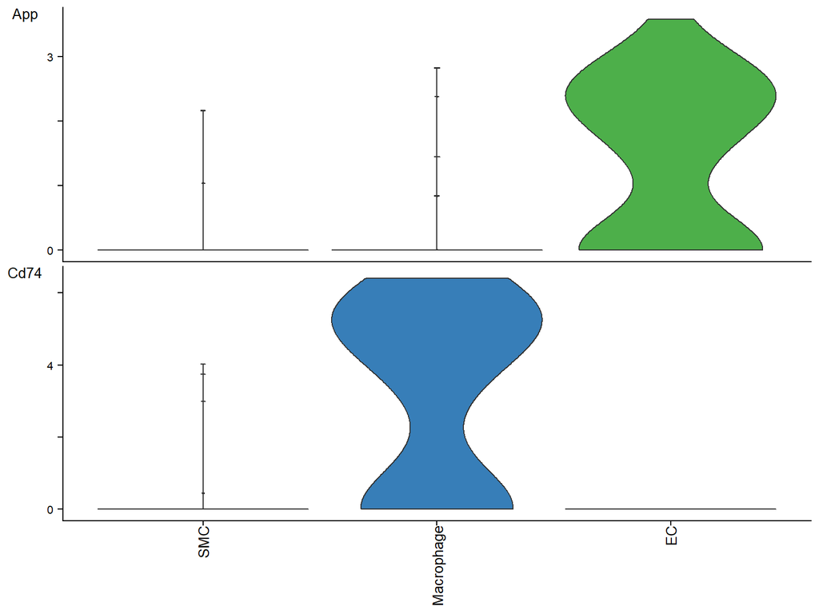

```r
## Gene expression
plotGeneExpression(cellchat, signaling = pathways.show)
```

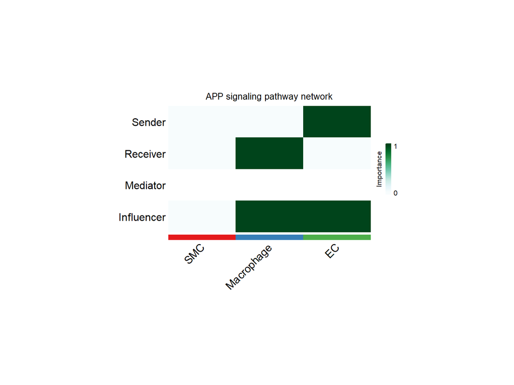

```r
## Network centrality measures
cellchat <- netAnalysis_computeCentrality(cellchat, slot.name = "netP") # the slot 'netP' means the inferred intercellular communication network of signaling pathways
netAnalysis_signalingRole_network(cellchat, signaling = pathways.show, width = 8, height = 5, font.size = 12)
```

As seen above, the communication probability heatmap (top) again makes it clear that the endothelial cells are likely sending a signal to the macrophages (on average) via the APP pathway. This is consistent with the expression data for the *App-Cd74* pair, which shows endothelial cells uniquely expressing App and macrophages uniquely expressing Cd74 (middle). Finally, the network analysis for this pathway again shows ECs as senders (high out-degree) and macrophages as receivers (high in-degree), but also has both cell types as influencers (high information centrality) [2]. While I do not find information centrality as intuitive to understand as other centrality measures, it seems to be based on applying similar math to the edges of the network as the math used to express electrical resistance in order to determine the “ease of information flow” within the network. I think the resistance values are used instead of shortest pathways in a calculation analogous to closeness centrality [3,4]. Either way, it seems that this pathway is important within the cell-cell communication network for more than just its dominance in EC-to-macrophage communication. It sounds like high information centrality nodes within the network do tend to have a high number of relatively short paths to all others (like those with a high closeness centrality), and are important for the overall control of information moving through the network [3].

I was curious about what the literature has to say on the APP pathway and/or this pair within the context of the circulatory system and/or artery wall tissue. Surprisingly to me, Amyloid-beta precursor protein (App) and HLA class II histocompatibility antigen gamma chain (Cd74) both appear to be cell surface receptors [6,7]. So, this pathway may represent a more direct “receptor-receptor” (i.e. cell-cell) interaction between ECs and macrophages, unless one of these proteins is some how cleaved or otherwise released from the cell surface as a soluble form. Direct interaction seems plausible, as macrophages are quite mobile and could easily reach the endothelial cells lining the artery. It sounds like Cd74 expression is elevated in atherosclerotic plaques, particularly in the inflammatory portions of the plaques [8]. In macrophages, Cd74 is the main receptor for macrophage migration inhibitory factor (MIF), a cytokine whose signaling is associated with cardiovascular pathology [7,9,10]. The *App-Cd74* axis was found to be central to endothelial cell to macrophage communication within the context of kidney injury and the overactive immune response that helps drive the subsequent damage. It also sounds like App expression in ECs can increase the level of Cd74 expression in macrophages, so there is potential for signaling via this route to ramp itself up (i.e. positive feedback) [11]. While that cited study was done in a different tissue and context, it may support that the connection above indicates a potentially harmful immune response instigated by signaling from endothelial cells in the arterial wall (especially given that Cd74 is associated with cardiovascular disease/pathology, as cited earlier).

*As a side note, I did not find much context on this data set. The data set from the lecture notes this week was said to be sampled from the arterial arch, which is what I am assuming “AA” stood for in that .rds file. “TA” in this file could stand for thoracic aorta, indicating that this data came from cells in a straighter section of the aorta (although that interpretation might not square with the biological context that presented above). Regardless, due to the file naming, it seems likely that this sample came from the arterial wall at a different location (or experimental setup/condition) than that of this week’s example data (i.e. “s_obj_AA_M.rds”).*

## EC autocrine

As discussed earlier, *Cdh5-Cdh5* and *Pecam1-Pecam1* were the highest probability routes of autocrine signaling between EC cells, but *Col4a1-(Itga1+Itgb1)*, *Col4a2-(Itga1+Itgb1)*, and *Ppia-Bsg* also had moderate probabilities. I start with the highest probability pathways below:

### Highest probabillity

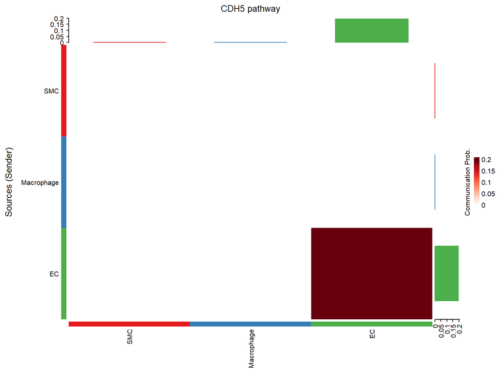

```r
## Starting with Cdh5-Cdh5
pathways.show <- cellchat@LR$LRsig$pathway_name[grepl("Cdh5_Cdh5", cellchat@LR$LRsig$interaction_name, ignore.case = TRUE)]
## Heatmap
netVisual_heatmap(cellchat, signaling = pathways.show, color.heatmap = "Reds", title.name = paste(pathways.show, "pathway"))
```

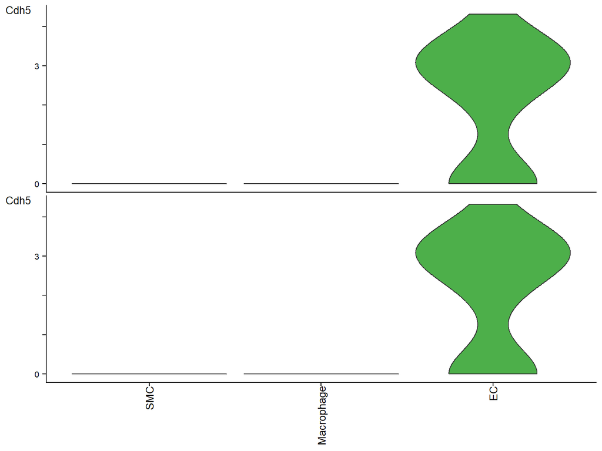

```r
## Gene expression
plotGeneExpression(cellchat, signaling = pathways.show)
```

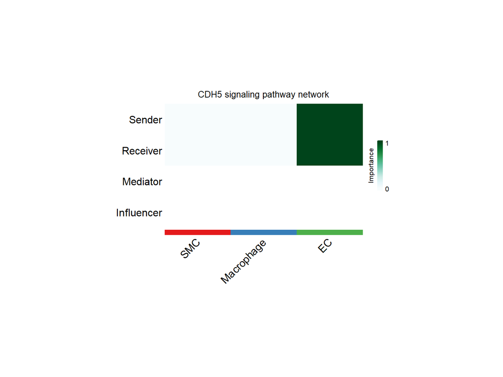

```r
## Network centrality measures
netAnalysis_signalingRole_network(cellchat, signaling = pathways.show, width = 8, height = 5, font.size = 12)
```

The plots above for the CDH5 pathway are all consistent with this communication occurring strictly between EC cells. What I found interesting about this pathway is that Cdh5 is a cadherin, meaning this finding indicates direct cell-cell adhesion between the adjacent endothelial cells in the artery wall [12]. In fact, this cadherin is specific to endothelial cells and critical for vascular permeability and regulation of processes like growth, proliferation, apoptosis in endothelial layers (during development or maintenance) [12, 13]. As such this pathway appears to represent important normal function of endothelial cells. This should not be surprising given the structural organization of artery wall tissue, but I still found it cool to see evidence of direct interaction between the (presumably) neighboring endothelial cells on the interior of the artery.

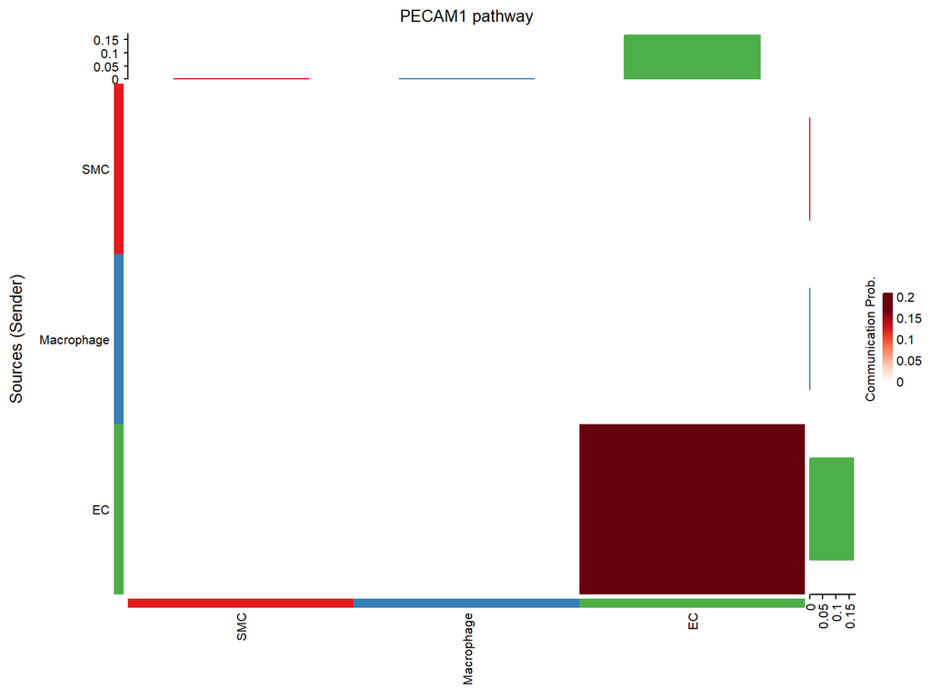

```r
## Onto Pecam1-Pecam1
pathways.show <- cellchat@LR$LRsig$pathway_name[grepl("Pecam1_Pecam1", cellchat@LR$LRsig$interaction_name, ignore.case = TRUE)]
## Heatmap
netVisual_heatmap(cellchat, signaling = pathways.show, color.heatmap = "Reds", title.name = paste(pathways.show, "pathway"))
```

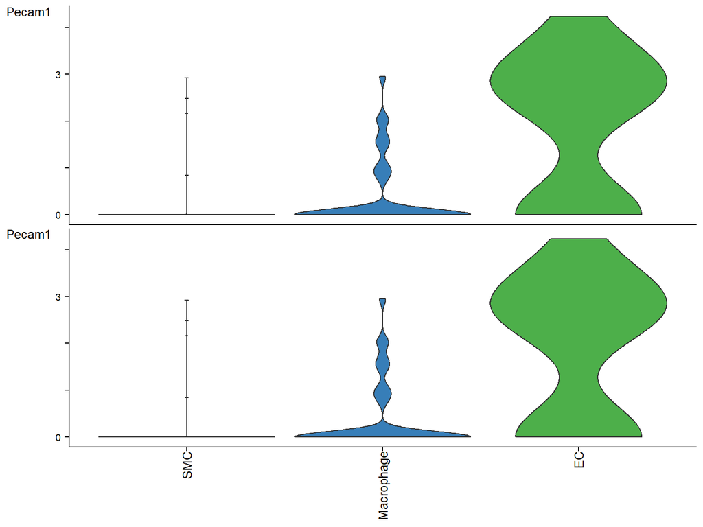

```r
## Gene expression
plotGeneExpression(cellchat, signaling = pathways.show)
```

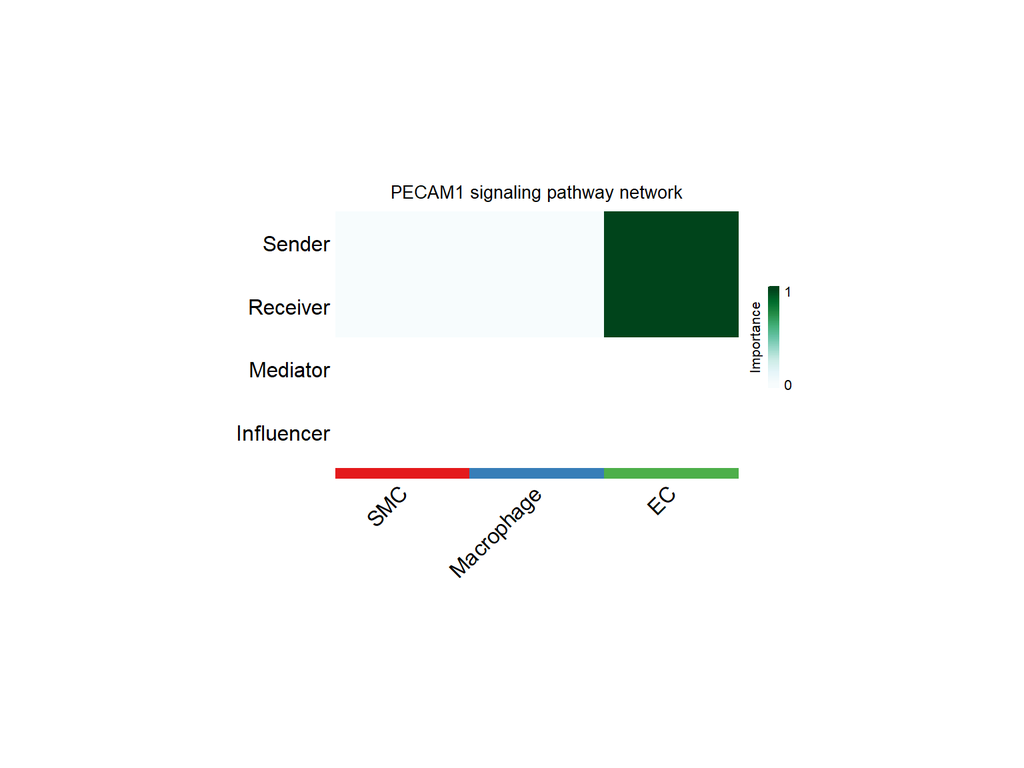

```r
## Network centrality measures
netAnalysis_signalingRole_network(cellchat, signaling = pathways.show, width = 8, height = 5, font.size = 12)
```

Again, the plots above put the PECAM1 pathway strongly in the “EC-EC signaling only” category. Interestingly, there was weak expression of Pecam1 in the macrophages (middle plot). Like Cdh5, Pecam1 is another molecule involved in cell adhesion. It sounds like this cell adhesion molecule is also important for the normal function of the endothelial layer. That said, while we do not have data on other cell types to support its occurrence here, Pecam1 signaling is also important for endothelial cells to regulate/permit various immune cells, such as white blood cells, to move from the blood into the surrounding tissues [14]. As such, this signal could represent boilerplate or pathogenic communication in the endothelial cells, but I wound need more context to be more confident as to which it is more likely to be. Interestingly, UniProt states that, based on structural similarity, Pecam1 may drive susceptibility to atherosclerosis [14].

### More moderate probabillities

Below, the remaining top pairs are addressed: *Col4a1-(Itga1+Itgb1)*, *Col4a2-(Itga1+Itgb1)*, and *Ppia-Bsg*. As discussed earlier, the bubble plot of outgoing EC signaling revealed many significant modes of EC-EC communication, but for simplicity I am only focusing on the “top pathways” and these pairs are where I drew the line (based somewhat arbitrarily on bubble plot color).

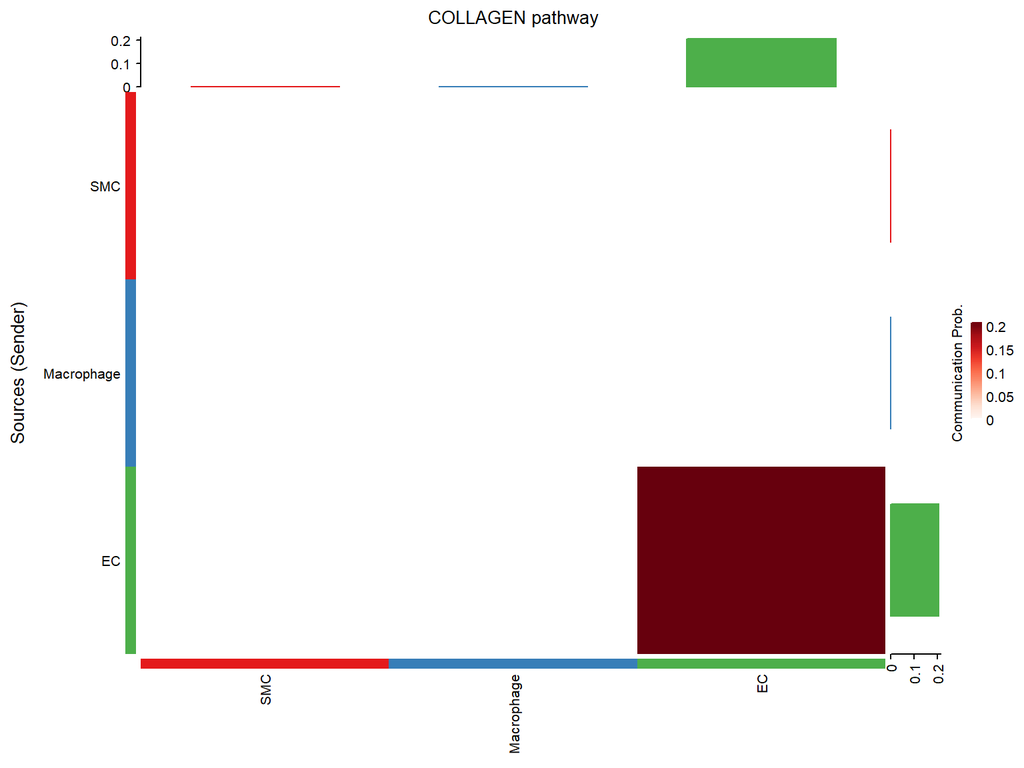

```r
## Col4a1-(Itga1+Itgb1) and Col4a2-(Itga1+Itgb1)
pathways.show <- unique(cellchat@LR$LRsig$pathway_name[grepl("Col4a", cellchat@LR$LRsig$interaction_name, ignore.case = TRUE)])
## Heatmap
netVisual_heatmap(cellchat, signaling = pathways.show, color.heatmap = "Reds", title.name = paste(pathways.show, "pathway"))
```

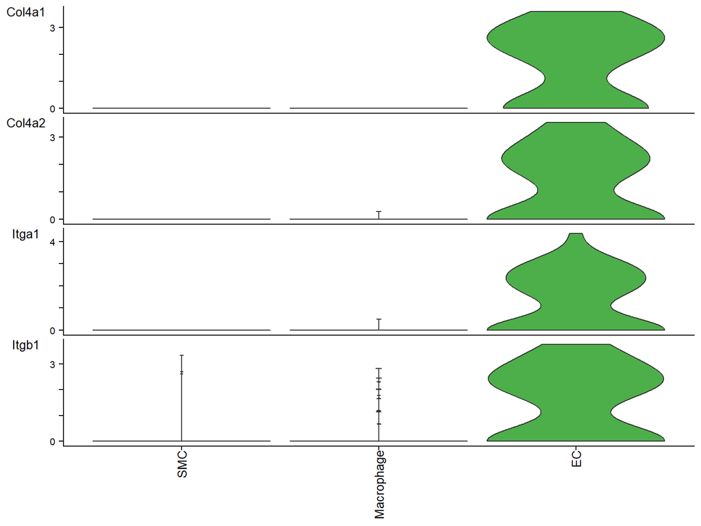

```r
## Gene expression
plotGeneExpression(cellchat, signaling = pathways.show)
```

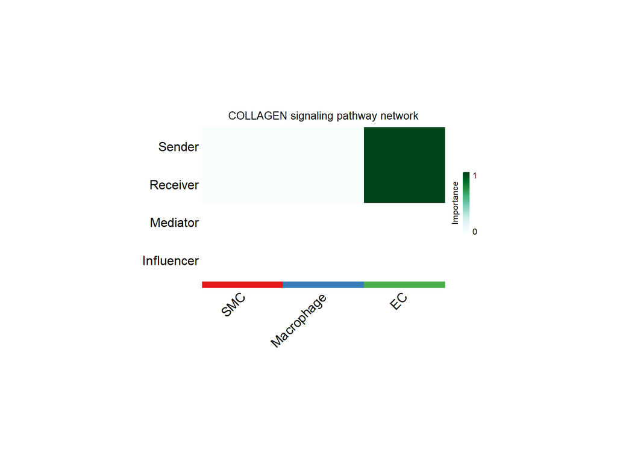

```r
## Network centrality measures
netAnalysis_signalingRole_network(cellchat, signaling = pathways.show, width = 8, height = 5, font.size = 12)
```

Interestingly, while the Collagen pathway above is labeled as being involved in EC-EC communication because those are the cell types expressing the pair components, it may additionally reflect the signals that EC cells receive from their connection to the extracellular matrix (ECM). Col4a1 and Col4a2 are components of Type 4 collagen, which is the major structural component of the basement membrane, i.e. the part of the ECM that sits just below the endothelial cell layer [15,16]. That said, a domain from either of these proteins can function alone (i.e. as arresten or canstatin, respectively) and both can inhibit angiogenesis in endothelial cells, among other things [15,16]. Itga1+Itgb1 is a receptor that detects anchorage to collagen and laminin and negatively regulates growth induced by EGF [17]. Similar to the CDH5 pathway discussed above, while this pathway could reflect pathology, it also seems possible that it simply reflects the normal interactions we would expect between ECs and their surroundings (i.e. neighboring EC cells, and possibly even the ECM).

As for *Ppia-Bsg* (i.e. the CypA pathway), it turns out that macrophages are the dominant senders of signals via this route, even though there is also some EC autocrine activity. Because of this, CypA has been given its own dedicated discussion in the next section on macrophages, and I will cover EC autocrine signaling there as well.

# **Macrophages as senders**

Below, I again use the chord diagram and bubble plot to explore the dominant pairs involved in signals sent by macrophages:

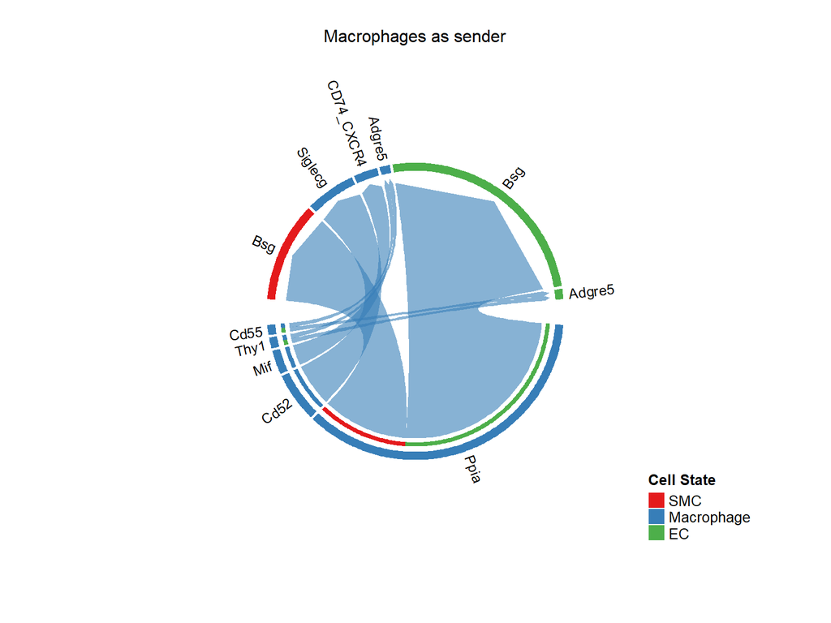

```r
sender <- idx["Macrophage"]
receiver <- idx[c("EC", "Macrophage", "SMC")]

## Chord diagram
netVisual_chord_gene(cellchat, sources.use = sender, targets.use = receiver, title.name = "Macrophages as sender")
```

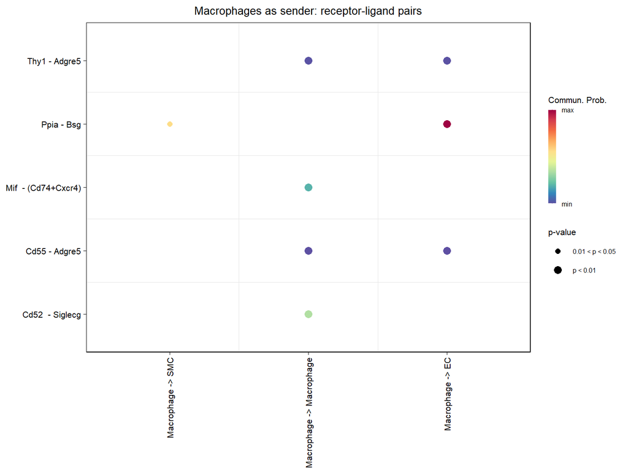

```r
## Bubble plot
netVisual_bubble(cellchat, sources.use = sender, targets.use = receiver, remove.isolate = FALSE, title.name = "Macrophages as sender: receptor-ligand pairs")
```

As seen above, the highest-probability pair is *Ppia-Bsg* (i.e. CypA pathway). This pair seems compelling and dominates the signals detected from macrophages to endothelial cells, and it is also somewhat important in EC-EC signaling, as noted earlier. This pair is also possibly involved in macrophage-SMC communication and it is the only detected connection involving SMCs. There is a moderate relative probability for the connection, but this pair has a marginal p-value for macrophages-to-SMCs. While statistically significant, none of the probabilities are as high for macrophage-macrophage communication, but I will discuss the top 2 autocrine pairs later: *Cd52-Siglecg* and *Mif-(Cd74+Cxcr4)*. The latter pair was included mainly because it relates closely to what was discussed earlier about *App-Cd74* communication from ECs to macrophages.

## CypA Pathway

Seeing as though this pathway was identified as important for signals sent by Macrophages to both endothelial cells and smooth muscle cells, as well as the EC autocrine signaling mentioned earlier, this pathway seemed to merit its own dedicated section and further discussion:

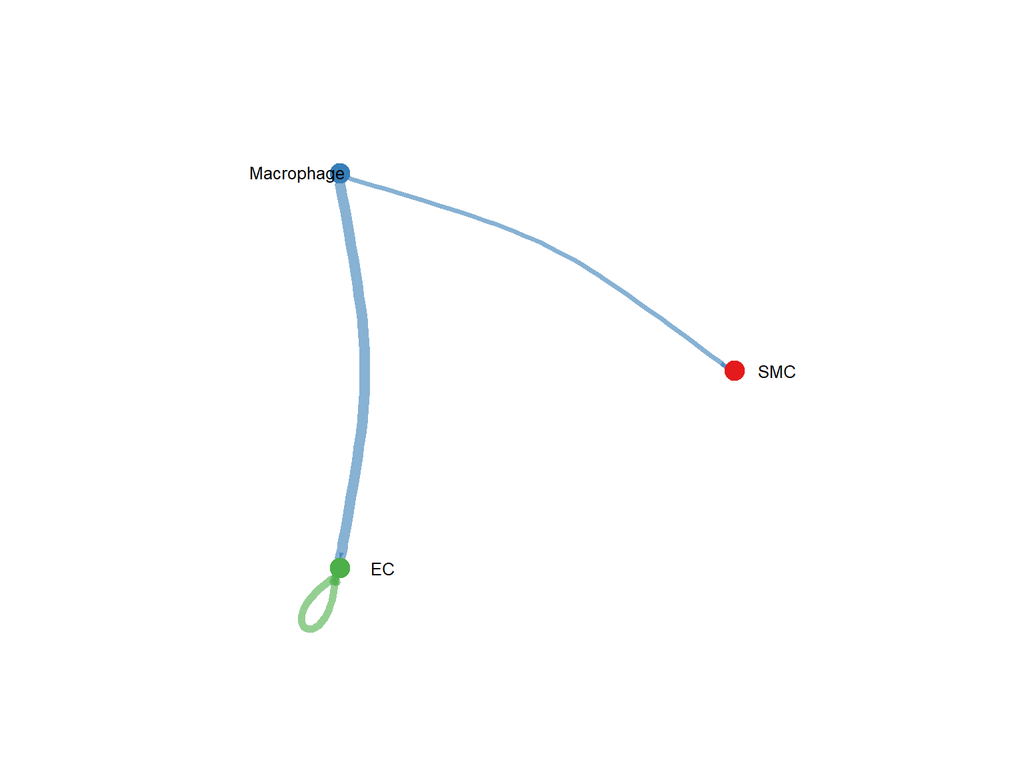

```r
## Ppia-Bsg
pathways.show <- cellchat@LR$LRsig$pathway_name[grepl("Ppia_Bsg", cellchat@LR$LRsig$interaction_name, ignore.case = TRUE)]
## Node connections
netVisual_aggregate(cellchat, signaling = pathways.show, layout = "circle")
```

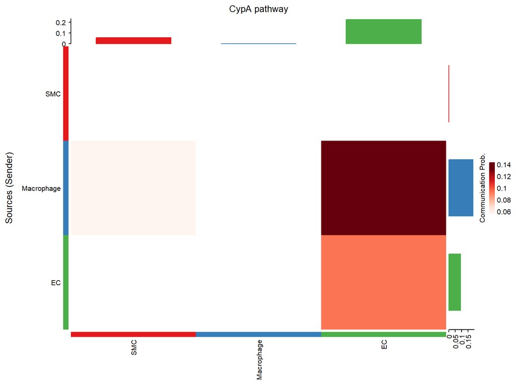

```r
## Heatmap
netVisual_heatmap(cellchat, signaling = pathways.show, color.heatmap = "Reds", title.name = paste(pathways.show, "pathway"))
```

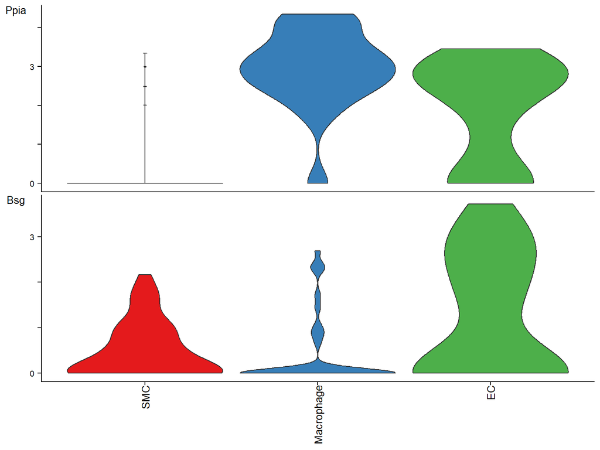

```r
## Gene expression
plotGeneExpression(cellchat, signaling = pathways.show)
```

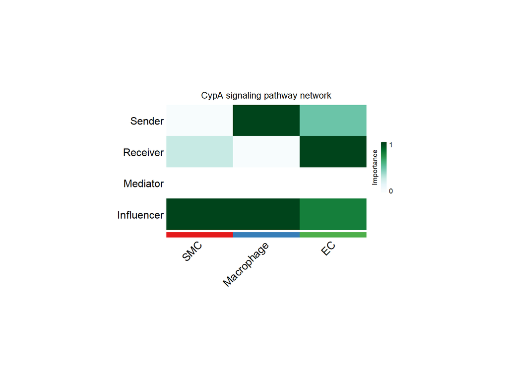

```r
## Network centrality measures
netAnalysis_signalingRole_network(cellchat, signaling = pathways.show, width = 8, height = 5, font.size = 12)
```

As seen above, while there is certainly support for active EC autocrine signaling via the CypA pathway, the macrophages seem to be expressing/“sending” Ppia the most unanimously. Extracellular Ppia (aka CypA) has long been known to be secreted by multiple vascular tissue components, including macrophages and ECs, and it is associated with arteriosclerosis and other cardiovascular issues [17,18]. CypA is known to activate pro-inflammatory pathways within ECs and promote the proliferation and migration of smooth muscle cells in vascular tissues [18]. So, the cell-cell communication pathways shown above may indeed represent evidence of cardiovascular pathology. Interestingly, not so long ago, a group found that the CypA-Bsg axis promoted cardiac fibrosis and other harmful phenotypes in the hearts of rats. They also found that treatment with a suppressor of Bsg-CypA signaling (celastrol) decreased pathogenic phenotypes in pulmonary smooth muscle cells and alleviated certain dysfunctional phenotypes in the hearts of mice [19]. Given this context, the pathways above paint a picture of macrophages inducing or sustaining an inflammatory response and/or other harmful phenomena in the artery wall via the CypA pathway, particularly via its influence on ECs, but also SMCs to a lesser extent. Endothelial cells seem to be stimulating their own (possibly harmful) response as well via CypA.

## Macrophage autocrine

The 2 most compelling autocrine pathways for the macrophages are covered below. That said, although they were significant, these pairs did not have very high probabilities compared to some of the others discussed so far.

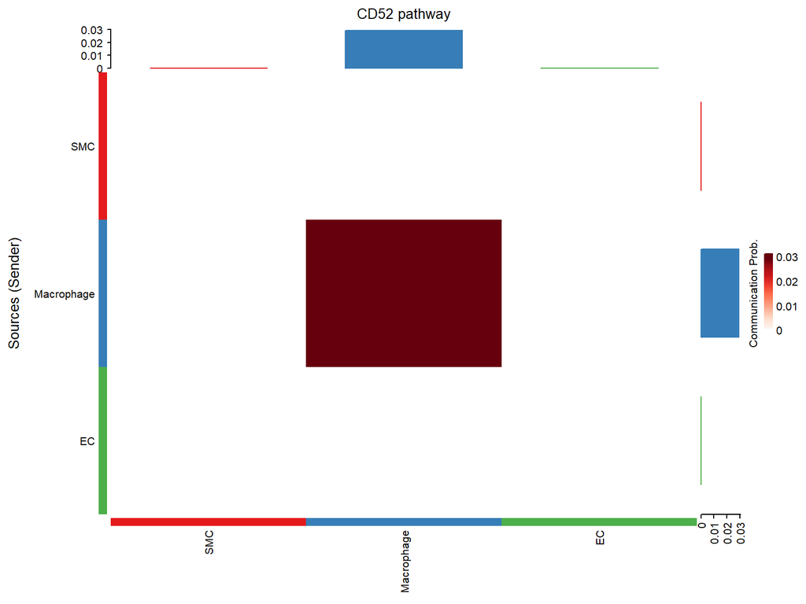

```r
## Cd52-Siglecg
pathways.show <- cellchat@LR$LRsig$pathway_name[grepl("Cd52_Siglecg", cellchat@LR$LRsig$interaction_name, ignore.case = TRUE)]
## Heatmap
netVisual_heatmap(cellchat, signaling = pathways.show, color.heatmap = "Reds", title.name = paste(pathways.show, "pathway"))
```

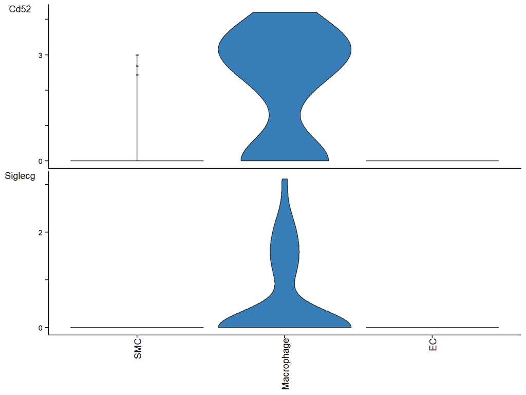

```r
## Gene expression
plotGeneExpression(cellchat, signaling = pathways.show)
```

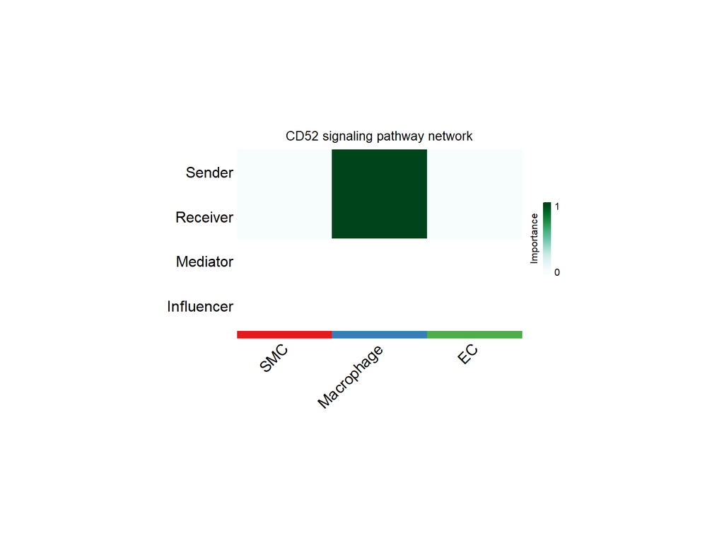

```r
## Network centrality measures
netAnalysis_signalingRole_network(cellchat, signaling = pathways.show, width = 8, height = 5, font.size = 12)
```

As seen above, we have a fairly simple picture of the CD52 pathway being used by “macrophages for macrophages”. The connection probability for this pair is fairly weak compared to some of the others shown earlier (top plot). This is not too surprising, as the distribution of Siglecg (aka Siglec10) expression in the macrophages is not very compelling (i.e. a bit too bottom heavy). Interestingly, this potentially seems to be another “receptor-receptor” pair, possibly indicating direct interactions between the macrophages [20,21]. I had trouble finding literature context specific to cardiovascular diseases, however, it sounds like this CD52 pathway can play a role in regulating the immune response, e.g. by suppressing activation of helper T cells, among other things [22,23]. We obviously do not have the corresponding data here, but it would have been interesting to see if other types of cells (like certain T cell subtypes) were also expressing Siglecg in this experiment. As for macrophages, it sounds like Cd52 suppresses their production of pro-inflammatory cytokines, and it can do the same thing other innate immune cells [23]. Overall, given the literature just cited, it seems more likely that this connection represents immune suppression and control (rather than activation).

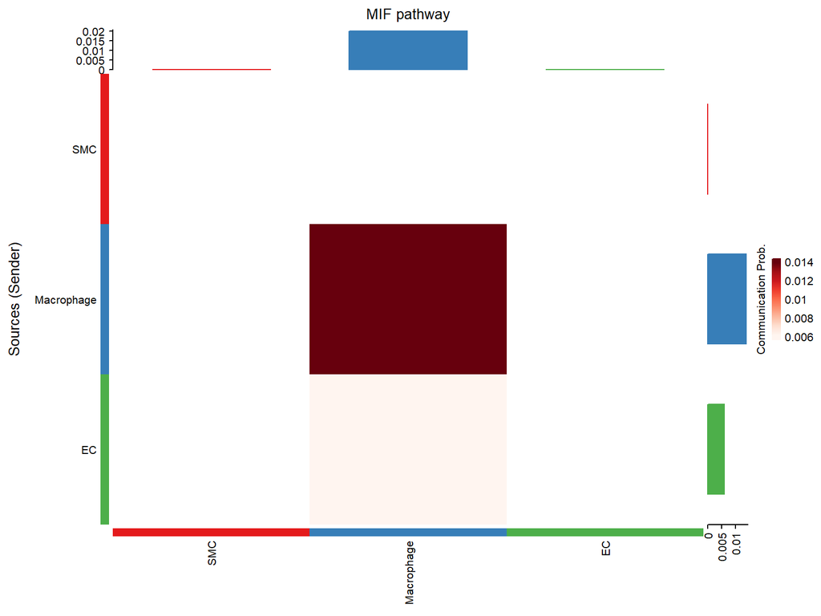

```r
## Mif-(Cd74+Cxcr4)
pathways.show <- unique(cellchat@LR$LRsig$pathway_name[grepl("Mif", cellchat@LR$LRsig$interaction_name, ignore.case = TRUE)])
## Heatmap
netVisual_heatmap(cellchat, signaling = pathways.show, color.heatmap = "Reds", title.name = paste(pathways.show, "pathway"))
```

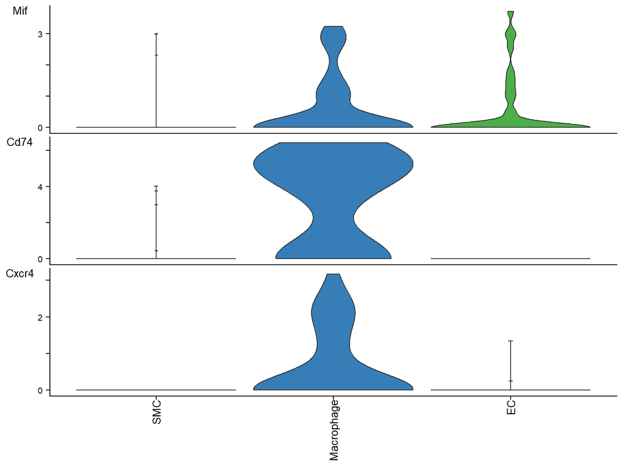

```r
## Gene expression
plotGeneExpression(cellchat, signaling = pathways.show)
```

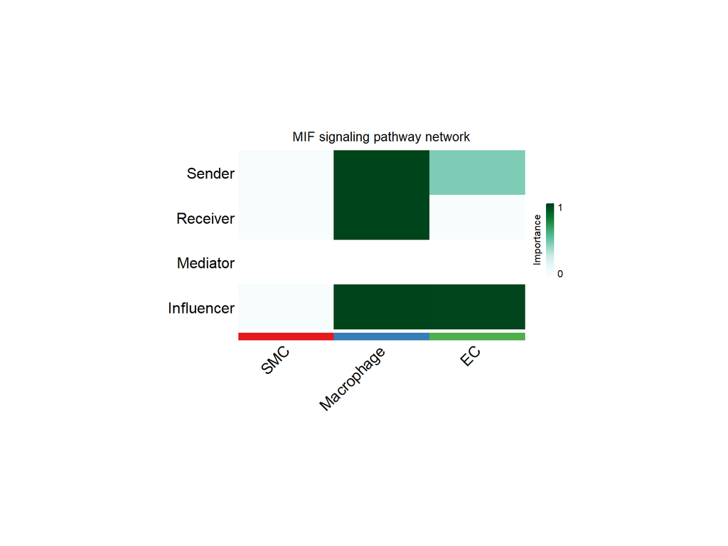

```r
## Network centrality measures
netAnalysis_signalingRole_network(cellchat, signaling = pathways.show, width = 8, height = 5, font.size = 12)
```

I almost did not cover this pathway, because the probability was somewhat weak compared to other pairs covered earlier on. However, I realized that this MIF pathway is quite relevant to my earlier discussion about the APP pathway (App-Cd74) signaling from ECs to macrophages, which was the most compelling connection between those cell types. As discussed earlier, Cd74 expression and signaling seems to be associated with inflammation in cardiovascular disease, namely at atherosclerotic plaques [8]. Also, EC expression of App and subsequent signaling via Cd74 in macrophages (for which there is support here) can stimulate further expression of Cd74 [11]. Cd74’s better-known ligand is macrophage migration inhibitory factor (MIF), which, as seen above, is also an active route of macrophage autocrine communication. Mif is a pro-inflammatory cytokine whose elevated expression/presence in the hearts of mice was associated with harmful phenotypes (dependent on Cd74) [9]. Mif signaling has also been implicated in atherosclerosis, among others diseases, and it it is involved in regulating processes like angiogenesis, cell proliferation, and fibrosis [10]. While the MIF pathway is largely being used for macrophage autocrine signaling in this experiment, from the expression and network plots (middle and bottom) we can see a slightly more complicated picture, with macrophages as influencers (not just senders and receivers) and ECs as weak senders and strong influencers. This last point seems consistent with the fact discussed earlier that EC cells are dominantly sending to macrophages on the closely-related APP pathway, which shares Cd74 and likely affects its expression.

# **Summary**

When digging into these receptor-ligand pairs a bit, I was excited by how many of them possibly indicate communication via more direct cell-cell interactions. Of course, in some cases the interpretation is somewhat dependent on the specific form of one protein from the pair (e.g. soluble versus membrane-bound). That said, pathways like CDH5 seem to pretty clearly represent direct cell-cell contact. This highlights the importance of proximity and spatial organization when it comes to coordination of cellular activity within just about any tissue [24], including that of the artery walls.

# **References**

*In addition to the Week 4 Topic Notes by Professor Gongol:*

[1] https://github.com/jinworks/CellChat/issues/185

[2] Jin, S., Guerrero-Juarez, C. F., Zhang, L., Chang, I., Ramos, R., Kuan, C.-H., Myung, P., Plikus, M. V., & Nie, Q. (2021). Inference and analysis of cell-cell communication using CellChat. In Nature Communications (Vol. 12, Issue 1). Springer Science and Business Media LLC. https://doi.org/10.1038/s41467-021-21246-9

[3] https://www.centiserver.ir/centrality/Information_Centrality/

[4] Brandes, U., & Fleischer, D. (2005). Centrality Measures Based on Current Flow. In Lecture Notes in Computer Science (pp. 533–544). Springer Berlin Heidelberg. https://doi.org/10.1007/978-3-540-31856-9_44

[5] https://en.wikipedia.org/wiki/Thoracic_aorta

[6] https://www.uniprot.org/uniprotkb/P05067/entry

[7] https://www.uniprot.org/uniprotkb/P04233/entry

[8] Martin-Ventura, J. L., Madrigal-Matute, J., Munoz-Garcia, B., Blanco-Colio, L. M., Van Oostrom, M., Zalba, G., Fortuno, A., Gomez-Guerrero, C., Ortega, L., Ortiz, A., Diez, J., & Egido, J. (2009). Increased CD74 expression in human atherosclerotic plaques: contribution to inflammatory responses in vascular cells. In Cardiovascular Research (Vol. 83, Issue 3, pp. 586–594). Oxford University Press (OUP). https://doi.org/10.1093/cvr/cvp141

[9] Cheng, W.-L., Kao, Y.-H., Chen, Y.-C., Lin, Y.-K., Chen, S.-A., & Chen, Y.-J. (2020). Macrophage migration inhibitory factor increases atrial arrhythmogenesis through CD74 signaling. In Translational Research (Vol. 216, pp. 43–56). Elsevier BV. https://doi.org/10.1016/j.trsl.2019.10.002

[10] Li, Q.-L., Tang, J., Zhao, L., Ruze, A., Shan, X.-F., & Gao, X.-M. (2023). The role of CD74 in cardiovascular disease. In Frontiers in Cardiovascular Medicine (Vol. 9). Frontiers Media SA. https://doi.org/10.3389/fcvm.2022.1049143

[11] Liu, B., Li, F., Wang, Y., Gao, X., Li, Y., Wang, Y., & Zhou, H. (2024). APP-CD74 axis mediates endothelial cell-macrophage communication to promote kidney injury and fibrosis. In Frontiers in Pharmacology (Vol. 15). Frontiers Media SA. https://doi.org/10.3389/fphar.2024.1437113

[12] https://www.uniprot.org/uniprotkb/P33151/entry

[13] Vestweber, D. (2008). VE-Cadherin. In Arteriosclerosis, Thrombosis, and Vascular Biology (Vol. 28, Issue 2, pp. 223–232). Ovid Technologies (Wolters Kluwer Health). https://doi.org/10.1161/atvbaha.107.158014

[14] https://www.uniprot.org/uniprotkb/P16284/entry

[15] https://www.uniprot.org/uniprotkb/P02462/entry

[16] https://www.uniprot.org/uniprotkb/P08572/entry

[17] Satoh, K. (2015). Cyclophilin A in Cardiovascular Homeostasis and Diseases. In The Tohoku Journal of Experimental Medicine (Vol. 235, Issue 1, pp. 1–15). Tohoku University Medical Press. https://doi.org/10.1620/tjem.235.1

[18] https://www.uniprot.org/uniprotkb/P62937/entry

[19] Kurosawa, R., Satoh, K., Nakata, T., Shindo, T., Kikuchi, N., Satoh, T., Siddique, M. A. H., Omura, J., Sunamura, S., Nogi, M., Takeuchi, Y., Miyata, S., & Shimokawa, H. (2021). Identification of Celastrol as a Novel Therapeutic Agent for Pulmonary Arterial Hypertension and Right Ventricular Failure Through Suppression of Bsg (Basigin)/CyPA (Cyclophilin A). In Arteriosclerosis, Thrombosis, and Vascular Biology (Vol. 41, Issue 3, pp. 1205–1217). Ovid Technologies (Wolters Kluwer Health). https://doi.org/10.1161/atvbaha.120.315731

[20] https://www.ncbi.nlm.nih.gov/gene/117054

[21] https://www.uniprot.org/uniprotkb/Q96LC7/entry

[22] Bandala-Sanchez, E., G. Bediaga, N., Goddard-Borger, E. D., Ngui, K., Naselli, G., Stone, N. L., Neale, A. M., Pearce, L. A., Wardak, A., Czabotar, P., Haselhorst, T., Maggioni, A., Hartley-Tassell, L. A., Adams, T. E., & Harrison, L. C. (2018). CD52 glycan binds the proinflammatory B box of HMGB1 to engage the Siglec-10 receptor and suppress human T cell function. In Proceedings of the National Academy of Sciences (Vol. 115, Issue 30, pp. 7783–7788). Proceedings of the National Academy of Sciences. https://doi.org/10.1073/pnas.1722056115

[23] Rashidi, M., Bandala-Sanchez, E., Lawlor, K. E., Zhang, Y., Neale, A. M., Vijayaraj, S. L., O’Donoghue, R., Wentworth, J. M., Adams, T. E., Vince, J. E., & Harrison, L. C. (2017). CD52 inhibits Toll-like receptor activation of NF-κB and triggers apoptosis to suppress inflammation. In Cell Death & Differentiation (Vol. 25, Issue 2, pp. 392–405). Springer Science and Business Media LLC. https://doi.org/10.1038/cdd.2017.173

[24] Armingol, E., Officer, A., Harismendy, O., & Lewis, N. E. (2020). Deciphering cell–cell interactions and communication from gene expression. In Nature Reviews Genetics (Vol. 22, Issue 2, pp. 71–88). Springer Science and Business Media LLC. https://doi.org/10.1038/s41576-020-00292-x